# Reproducible Research: Peer Assessment 2

NirmaMary

Friday, April 24, 2015

## Impact of Severe Weather Events on Public Health and Economy in the United States

### Synopsis

In this report, we aim to analyze the impact of different weather events on public health and economy based on the storm database collected from the U.S. National Oceanic and Atmospheric Administration’s (NOAA) from 1950 - 2011. We will use the estimates of fatalities, injuries, property and crop damage to decide which types of event are most harmful to the population health and economy. From these data, we found that excessive heat and tornado are most harmful with respect to population health, while flood, drought, and hurricane/typhoon have the greatest economic consequences.

## Making sure of the Library Load.

```r
echo = TRUE  # Always make code visible
options(scipen = 1)  # Turn off scientific notations for numbers
library(knitr)
```

```r
library(ggplot2)
library(plyr)
library(R.utils)
library(dplyr)
require(gridExtra)
```

## Data Processing

We download the data file and store it in a dataframe.

```r
## Load data
download.file("http://d396qusza40orc.cloudfront.net/repdata%2Fdata%2FStormData.csv.bz2",
                      "./StormData.csv.bz2")
stormData <- read.csv(bzfile("StormData.csv.bz2"))
## Check the first 2 rows of the data before processing the data for the project.
head(stormData, n = 2)
```

```
##   STATE__          BGN_DATE BGN_TIME TIME_ZONE COUNTY COUNTYNAME STATE
## 1       1 4/18/1950 0:00:00     0130       CST     97     MOBILE    AL
## 2       1 4/18/1950 0:00:00     0145       CST      3    BALDWIN    AL
##    EVTYPE BGN_RANGE BGN_AZI BGN_LOCATI END_DATE END_TIME COUNTY_END
## 1 TORNADO         0                                               0
## 2 TORNADO         0                                               0
##   COUNTYENDN END_RANGE END_AZI END_LOCATI LENGTH WIDTH F MAG FATALITIES
## 1         NA         0                        14   100 3   0          0
## 2         NA         0                         2   150 2   0          0
##   INJURIES PROPDMG PROPDMGEXP CROPDMG CROPDMGEXP WFO STATEOFFIC ZONENAMES
## 1       15    25.0          K       0
## 2        0     2.5          K       0
##   LATITUDE LONGITUDE LATITUDE_E LONGITUDE_ REMARKS REFNUM
## 1     3040      8812       3051       8806              1
## 2     3042      8755          0          0              2
```

```r
norows <- nrow(stormData)
nocols <- ncol(stormData)
```

There are 902297 rows and 37 columns in total. The events in the database start in the year 1950 and end in November 2011. In the earlier years of the database there are generally fewer events recorded, most likely due to a lack of good records. More recent years should be considered more complete.

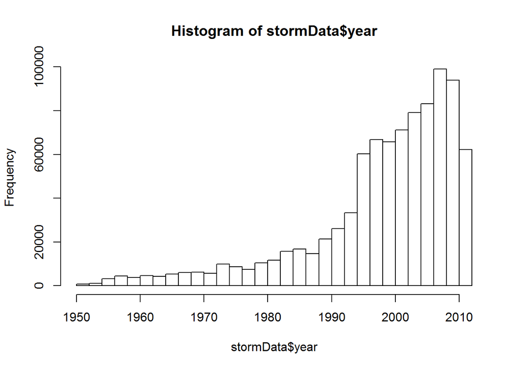

```r
stormData$year <- as.numeric(format(as.Date(stormData$BGN_DATE, format = "%m/%d/%Y %H:%M:%S"), "%Y"))
hist(stormData$year, breaks = 30)
```

```r
storm <- stormData[stormData$year >= 1995, ]
ndim <- dim(storm)
rm(stormData)  ## to free up memory
```

Now, there are 681500 rows and 38 columns in total in the storm dataset.

## Impact on Public Health

In this section, we check the number of fatalities and injuries that are caused by the severe weather events. We would like to get the first 15 most severe types of weather events.

```r
storm <- tbl_df(storm)
by_evtype <- group_by(storm, EVTYPE)
fatalities <- by_evtype %>%
        select(EVTYPE, FATALITIES) %>%
        summarise(FATALITY.COUNT = sum(FATALITIES)) %>%
        arrange(desc(FATALITY.COUNT))

injuries <- by_evtype %>%
        select(EVTYPE, INJURIES) %>%
        summarise(INJURY.COUNT = sum(INJURIES)) %>%
        arrange(desc(INJURY.COUNT))
```

Impact on Economy

We will convert the property damage and crop damage data into comparable numerical forms according to the meaning of units described in the code book (Storm Events). Both PROPDMGEXP and CROPDMGEXP columns record a multiplier for each observation where we have Hundred (H), Thousand (K), Million (M) and Billion (B).

```r
property <- by_evtype %>%
        select(EVTYPE, PROPDMG, PROPDMGEXP) %>%
        mutate(PROPDMGEXP = as.character(PROPDMGEXP)) %>%
        mutate(PROPDMGEXP = toupper(PROPDMGEXP))
property[which(property[3] == "B"), 3] <- "9"
property[which(property[3] == "M"), 3] <- "6"
property[which(property[3] == "K"), 3] <- "3"
property[which(property[3] == "H"), 3] <- "2"
property[which(property[3] == "+"), 3] <- "0"
property[which(property[3] == "-"), 3] <- "0"
property[which(property[3] == "?"), 3] <- "0"
property[which(property[3] == ""), 3] <- "0"

property <- property %>%
        mutate(PROPDMGEXP = as.numeric(PROPDMGEXP),
               propertyDamage = PROPDMG * 10^PROPDMGEXP) %>%
        select(EVTYPE, propertyDamage) %>%
        summarise(propertyDamage = sum(propertyDamage)) %>%
        arrange(desc(propertyDamage))

crop <- by_evtype %>%
        select(EVTYPE, CROPDMG, CROPDMGEXP) %>%
        mutate(CROPDMGEXP = as.character(CROPDMGEXP)) %>%
        mutate(CROPDMGEXP = toupper(CROPDMGEXP))
crop[which(crop[3] == "B"), 3] <- "9"
crop[which(crop[3] == "M"), 3] <- "6"
crop[which(crop[3] == "K"), 3] <- "3"
crop[which(crop[3] == "H"), 3] <- "2"
crop[which(crop[3] == "+"), 3] <- "0"
crop[which(crop[3] == "-"), 3] <- "0"
crop[which(crop[3] == "?"), 3] <- "0"
crop[which(crop[3] == ""), 3] <- "0"

crop <- crop %>%
        mutate(CROPDMGEXP = as.numeric(CROPDMGEXP),
               cropDamage = CROPDMG * 10^CROPDMGEXP) %>%
        select(EVTYPE, cropDamage) %>%
        summarise(cropDamage = sum(cropDamage)) %>%
arrange(desc(cropDamage))
```

Results

As for the impact on public health, we have got two sorted lists of severe weather events below by the number of people badly affected.

```r
fatalities
```

```
## Source: local data frame [799 x 2]
##
##            EVTYPE FATALITY.COUNT
## 1  EXCESSIVE HEAT           1903
## 2         TORNADO           1545
## 3     FLASH FLOOD            934
## 4            HEAT            924
## 5       LIGHTNING            729
## 6           FLOOD            423
## 7     RIP CURRENT            360
## 8       HIGH WIND            241
## 9       TSTM WIND            241
## 10      AVALANCHE            223
## ..            ...            ...
```

```r
injuries
```

```
## Source: local data frame [799 x 2]
##
##               EVTYPE INJURY.COUNT
## 1            TORNADO        21765
## 2              FLOOD         6769
## 3     EXCESSIVE HEAT         6525
## 4          LIGHTNING         4631
## 5          TSTM WIND         3630
## 6               HEAT         2030
## 7        FLASH FLOOD         1734
## 8  THUNDERSTORM WIND         1426
## 9       WINTER STORM         1298
## 10 HURRICANE/TYPHOON         1275
## ..               ...          ...
```

And the following is a pair of graphs of total fatalities and total injuries affected by these severe weather events.

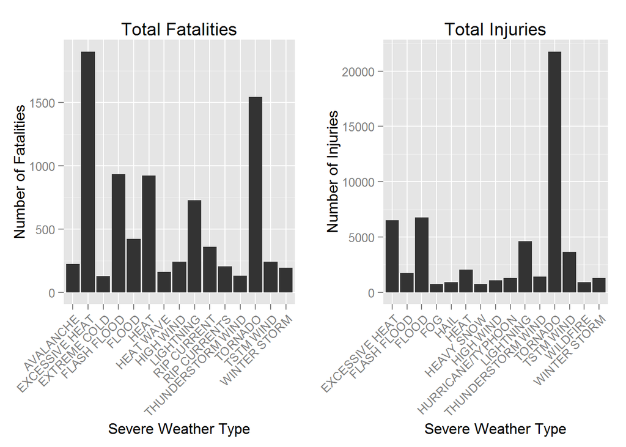

```r
fatalitiesPlot <- ggplot(slice(fatalities, 1:15), aes(EVTYPE, FATALITY.COUNT)) +
        geom_bar(stat = "identity") +
        scale_y_continuous("Number of Fatalities") +
        theme(axis.text.x = element_text(angle = 45, hjust = 1)) +
        xlab("Severe Weather Type") +
        ggtitle("Total Fatalities")

injuriesPlot <- ggplot(slice(injuries, 1:15), aes(EVTYPE, INJURY.COUNT)) +
        geom_bar(stat = "identity") +
        scale_y_continuous("Number of Injuries") +
        theme(axis.text.x = element_text(angle = 45, hjust = 1)) +
        xlab("Severe Weather Type") +
        ggtitle("Total Injuries")
grid.arrange(fatalitiesPlot, injuriesPlot, ncol = 2)
```

Based on the above histograms, we find that excessive heat and tornado cause most fatalities; tornado causes most injuries in the United States from 1995 to 2011.

As for the impact on economy, we have got two sorted lists below by the amount of money cost by damages.

```r
property
```

```
## Source: local data frame [799 x 2]
##
##               EVTYPE propertyDamage
## 1              FLOOD   144022037057
## 2  HURRICANE/TYPHOON    69305840000
## 3        STORM SURGE    43193536000
## 4            TORNADO    24935939545
## 5        FLASH FLOOD    16047794571
## 6               HAIL    15048722103
## 7          HURRICANE    11812819010
## 8     TROPICAL STORM     7653335550
## 9          HIGH WIND     5259785375
## 10          WILDFIRE     4759064000
## ..               ...            ...
```

```r
crop
```

```
## Source: local data frame [799 x 2]
##
##               EVTYPE  cropDamage
## 1            DROUGHT 13922066000
## 2              FLOOD  5422810400
## 3          HURRICANE  2741410000
## 4               HAIL  2614127070
## 5  HURRICANE/TYPHOON  2607872800
## 6        FLASH FLOOD  1343915000
## 7       EXTREME COLD  1292473000
## 8       FROST/FREEZE  1094086000
## 9         HEAVY RAIN   728399800
## 10    TROPICAL STORM   677836000
## ..               ...         ...
```

And the following is a pair of graphs of total property damage and total crop damage affected by these severe weather events.

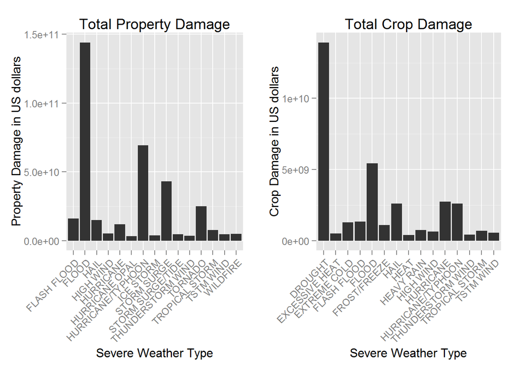

```r
propertyPlot <- ggplot(slice(property, 1:15), aes(EVTYPE, propertyDamage)) +
        geom_bar(stat = "identity") +
        theme(axis.text.x = element_text(angle = 45, hjust = 1)) +
        scale_y_continuous("Property Damage in US dollars") +
        xlab("Severe Weather Type") +
        ggtitle("Total Property Damage")

cropPlot<- ggplot(slice(crop, 1:15), aes(EVTYPE, cropDamage)) +
        geom_bar(stat = "identity") +
        theme(axis.text.x = element_text(angle = 45, hjust = 1)) +
        scale_y_continuous("Crop Damage in US dollars") +
        xlab("Severe Weather Type") + ggtitle("Total Crop Damage")
grid.arrange(propertyPlot, cropPlot, ncol = 2)
```

Based on the above histograms, we find that flood and hurricane/typhoon cause most property damage; drought and flood causes most crop damage in the United States from 1995 to 2011.

## Conclusion

From these data, we found that excessive heat and tornado are most harmful with respect to population health, while flood, drought, and hurricane/typhoon have the greatest economic consequences.